# a) Plot the ER_visit frequency

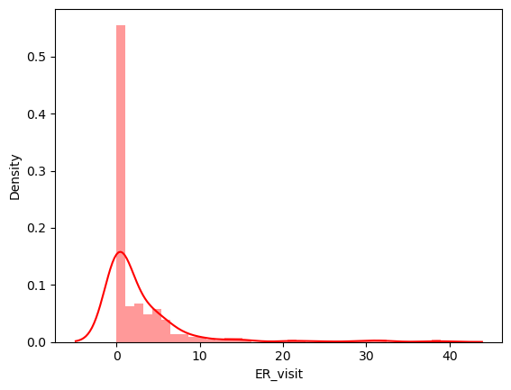

```python
# Import libraries
import seaborn as sns
import matplotlib.pyplot as plt
import pandas as pd

df=pd.read_csv('ER_visit.csv')
sns.distplot(df['ER_visit'], color='red')

# Display the plot
plt.show()
```

# b) Run the Poisson regression on all the variables and interpret the results.

```python
import statsmodels.api as sm
from statsmodels.formula.api import glm

# Fit Poisson regression of ER_visit by all other variables
model = glm('ER_visit ~ car + outdoor_activity + chronic_disease + household_history + gym', data = df, family = sm.families.Poisson()).fit()

# Display model results
print(model.summary())
```

```
                 Generalized Linear Model Regression Results
==============================================================================
Dep. Variable:               ER_visit   No. Observations:                  402
Model:                            GLM   Df Residuals:                      396
Model Family:                 Poisson   Df Model:                            5
Link Function:                    Log   Scale:                          1.0000
Method:                          IRLS   Log-Likelihood:                -1260.0
Date:                Sun, 11 Feb 2024   Deviance:                       1870.0
Time:                        13:06:13   Pearson chi2:                 2.50e+03
No. Iterations:                     6   Pseudo R-squ. (CS):             0.8185
Covariance Type:            nonrobust
=====================================================================================
                        coef    std err          z      P>|z|      [0.025      0.975]
-------------------------------------------------------------------------------------
Intercept            -1.0747      0.126     -8.511      0.000      -1.322      -0.827
car                   0.3466      0.067      5.147      0.000       0.215       0.479
outdoor_activity      0.5464      0.067      8.171      0.000       0.415       0.677
chronic_disease       0.0131      0.007      1.995      0.046       0.000       0.026
household_history     0.6732      0.033     20.431      0.000       0.609       0.738
gym                  -0.6867      0.038    -17.858      0.000      -0.762      -0.611
=====================================================================================
```

```python
model.params
```

```
Intercept           -1.074676
car                  0.346612
outdoor_activity     0.546414
chronic_disease      0.013073
household_history    0.673238
gym                 -0.686748
dtype: float64
```

```python
import numpy as np

# Compute and print he multiplicative effect
print(np.exp(model.params))
```

```
Intercept            0.341408
car                  1.414269
outdoor_activity     1.727049
chronic_disease      1.013159
household_history    1.960575
gym                  0.503210
dtype: float64
```

#### Intercept (const) - The model intercept is -1.0747, indicating the log count of ER visits when all the variables are 0. When all the variables are 0, the ER_visit is 0.34.

#### car: For a 1-unit increase in car (not having a car vs having a car), the mean response of y, i.e.lambda, will multiply by 1.41, or 41% increase in the estimated mean number of ER_visit. The coefficient for car ownership is 0.3466, suggesting that having a car is associated with an increase in the log count of ER visits. The relationship is statistically significant (p < 0.001), indicating a positive association between car ownership and ER visits.

#### outdoor_activity: For a 1-unit increase in outdoor_activity, keeping other variables unchanged, the mean response of y, i.e.lambda, will multiply by 1.73, or 73% increase in the estimated mean number of ER_visit. Participation in outdoor activities is associated with a 0.5464 increase in the log count of ER visits, also statistically significant (p < 0.001). This suggests that those engaging in outdoor activities have a higher count of ER visits.

#### chronic_disease:For a 1-unit increase in chronic_disease, the mean response of y, i.e.lambda, will multiply by 1.01, or 1% increase in the estimated mean number of ER_visit. The coefficient for chronic disease presence is 0.0131, with a p-value of 0.046, indicating a marginally significant positive relationship between having a chronic disease and the log count of ER visits.

#### household_history: For a 1-unit increase in household_history, the mean response of y, i.e.lambda, will multiply by 1.96, or 96% increase in the estimated mean number of ER_visit. An increase in household history of diseases is associated with a 0.6732 increase in the log count of ER visits, which is statistically significant (p < 0.001). This implies a strong positive association between household history and ER visits.

#### For a 1-unit increase in gym, the mean response of y, i.e.lambda, will multiply by 0.50, or 50% decrease in the estimated mean number of ER_visit. Gym membership is associated with a -0.6867 decrease in the log count of ER visits, and this relationship is statistically significant (p < 0.001). It suggests that having a gym membership is associated with fewer ER visits.

```python
# Compute and print sample mean of the number of ER_visit
ER_visit_mean = np.mean(df.ER_visit)
print('Sample mean:', round(ER_visit_mean, 2))

# Compute and print sample variance of the number of ER_visit
ER_visit_var = np.var(df.ER_visit)
print('Sample variance:', round(ER_visit_var, 2))

# Compute ratio of variance to mean
print('Ratio:', round(ER_visit_var/ER_visit_mean, 3))
```

```
Sample mean: 2.79
Sample variance: 29.48
Ratio: 10.57
```

```python
dispersion_ratio= model.pearson_chi2/model.df_resid
print(dispersion_ratio)
print ('If the ratio is close to 1 then it is assumed the data is drawn from the Poisson distribution, if it is smaller than 1 then it implies underdispersion and if greater than one it implied overdispersion. This is an approximation and there is no fixed threshold for an affirmative statistical intervention.')
```

[output not shown]

# c) Run the Negative Binomial regression. What kind of differences you observe in comparison with Poisson regression? Discuss/compare overdispersion in the models.

```python
#The negative binomial allows for the variance to exceed the mean.
import statsmodels.api as sm
import statsmodels.formula.api as smf

# Define the formula for the model fit
formula = 'ER_visit ~ car + outdoor_activity + chronic_disease + household_history + gym'

# Fit the GLM negative binomial model using log link function
negative_binomial_model = smf.glm(formula = formula, data = df, family = sm.families.NegativeBinomial()).fit()

# Print the negative binomial model's summary
print(negative_binomial_model.summary())
```

```
                 Generalized Linear Model Regression Results
==============================================================================
Dep. Variable:               ER_visit   No. Observations:                  402
Model:                            GLM   Df Residuals:                      396
Model Family:        NegativeBinomial   Df Model:                            5
Link Function:                    Log   Scale:                          1.0000
Method:                          IRLS   Log-Likelihood:                -772.66
Date:                Sun, 11 Feb 2024   Deviance:                       548.08
Time:                        13:06:13   Pearson chi2:                     788.
No. Iterations:                    20   Pseudo R-squ. (CS):             0.4108
Covariance Type:            nonrobust
=====================================================================================
                        coef    std err          z      P>|z|      [0.025      0.975]
-------------------------------------------------------------------------------------
Intercept            -2.0525      0.258     -7.970      0.000      -2.557      -1.548
car                   0.8825      0.142      6.214      0.000       0.604       1.161
outdoor_activity      1.2228      0.167      7.340      0.000       0.896       1.549
chronic_disease      -0.0044      0.014     -0.311      0.756      -0.032       0.023
household_history     0.7207      0.071     10.186      0.000       0.582       0.859
gym                  -0.8966      0.083    -10.759      0.000      -1.060      -0.733
=====================================================================================
```

### The Pearson chi2 statistic is approximately 788 with 396 degrees of freedom, suggesting that there might still be over-dispersion in the model

```python
# Define the formula for the model fit
formula = 'ER_visit ~ car + outdoor_activity + chronic_disease + household_history + gym'

# Fit the GLM negative binomial model using log link function
negative_binomial_model_alpha = glm(formula = formula, data = df, family = sm.families.NegativeBinomial(alpha = 1.5)).fit()

# Print the negative binomial model's summary
print(negative_binomial_model_alpha.summary())
```

```
                 Generalized Linear Model Regression Results
==============================================================================
Dep. Variable:               ER_visit   No. Observations:                  402
Model:                            GLM   Df Residuals:                      396
Model Family:        NegativeBinomial   Df Model:                            5
Link Function:                    Log   Scale:                          1.0000
Method:                          IRLS   Log-Likelihood:                -757.64
Date:                Sun, 11 Feb 2024   Deviance:                       438.91
Time:                        13:06:13   Pearson chi2:                     620.
No. Iterations:                    23   Pseudo R-squ. (CS):             0.3304
Covariance Type:            nonrobust
=====================================================================================
                        coef    std err          z      P>|z|      [0.025      0.975]
-------------------------------------------------------------------------------------
Intercept            -2.1364      0.295     -7.232      0.000      -2.715      -1.557
car                   0.9476      0.164      5.772      0.000       0.626       1.269
outdoor_activity      1.2843      0.193      6.642      0.000       0.905       1.663
chronic_disease      -0.0052      0.016     -0.317      0.751      -0.037       0.027
household_history     0.7253      0.082      8.825      0.000       0.564       0.886
gym                  -0.9330      0.097     -9.593      0.000      -1.124      -0.742
=====================================================================================
```

```python
dispersion_ratio_NB= negative_binomial_model_alpha.pearson_chi2/negative_binomial_model_alpha.df_resid
print(dispersion_ratio_NB)
```

```
1.5652861523129777
```

#### The Poisson model's dispersion_ratio is 6.3155056976797015. negative_binomial_model's dispersion_ratio 1.5652861523129777 is significantly lower than the Poisson model's dispersion_ratio.

#### We have negative coefficient of chronic_disease, meaning having chonoic disease. It says it is associated with decreased ER visits, which is not reasonable. The p value is so high meaning that the coeffcient is not significant.

#### The Negative Binomial model also have larger coefficient standard errors compared to the Poisson model. This is because the Negative Binomial model accounts for overdispersion by introducing an additional dispersion parameter.

#### The Negative Binomial model have much lower diviance level, which means taht the negative binomial model is a better fit.

#### Here, α is the dispersion parameter (or overdispersion parameter). A larger value of α indicates more overdispersion in the data. When α is 0, the Negative Binomial model reduces to a Poisson model (since the variance would then equal the mean, μ).

# d) Count the number of zero occurrences. Should we suspect from zero-inflation?

```python
import math
# Expected number of zero counts
exp_zero_cnt = ((ER_visit_mean**0)*np.exp(-ER_visit_mean))/math.factorial(0)

# Print exp_zero_counts
print('Expected zero counts given mean of ', round(ER_visit_mean,3),
      'is ', round(exp_zero_cnt,3)*100)

# Number of zero counts in sat variable
actual_zero_ant = sum(df['ER_visit'] == 0)

# Print the actual zero count observations in the sample
print('Actual zero counts in the sample: ', actual_zero_ant)
```

```
Expected zero counts given mean of  2.789 is  6.2
Actual zero counts in the sample:  195
```

### Yes, suspect zero-inflation

# e) Conduct a train test split with 80/20 ratio. Train zero inflated poisson regression and report RMSE. Finally visualize the actual vs predicted values on the test set.

```python
import numpy as np
import pandas as pd
import statsmodels.api as sm
from sklearn.model_selection import train_test_split
import matplotlib.pyplot as plt
from sklearn.metrics import mean_squared_error
```

#### The constant (or intercept) represents the expected value of the dependent variable when all the independent variables are equal to zero. Without an intercept, the regression model would be forced to pass through the origin (0,0), which often does not make sense in practical scenarios. Including an intercept allows the model to account for the average outcome when all predictors are absent, providing a more accurate and interpretable model.

```python
# Splitting the data into training and testing sets
train_data, test_data = train_test_split(df, test_size=0.2, random_state=42)

# Preparing the data for the model
X_train = train_data[['car', 'outdoor_activity', 'chronic_disease', 'household_history', 'gym']]
y_train = train_data['ER_visit']
X_test = test_data[['car', 'outdoor_activity', 'chronic_disease', 'household_history', 'gym']]
y_test = test_data['ER_visit']
```

```python
# Add a constant to the model (intercept)
X_train_const = sm.add_constant(X_train)
X_test_const = sm.add_constant(X_test)

# X_train_const = X_train
# X_test_const = X_test
```

```python
# Train a Zero-Inflated Poisson model
zip_model = sm.ZeroInflatedPoisson(endog=y_train, exog=X_train_const, exog_infl=X_train_const, inflation='logit').fit()
```

```
         Current function value: 2.316294
         Iterations: 35
         Function evaluations: 41
         Gradient evaluations: 41
```

```python
print(zip_model.summary())
```

```
                     ZeroInflatedPoisson Regression Results
===============================================================================
Dep. Variable:                ER_visit   No. Observations:                  321
Model:             ZeroInflatedPoisson   Df Residuals:                      315
Method:                            MLE   Df Model:                            5
Date:                 Sun, 11 Feb 2024   Pseudo R-squ.:                  0.2525
Time:                         13:06:13   Log-Likelihood:                -743.53
converged:                       False   LL-Null:                       -994.67
Covariance Type:             nonrobust   LLR p-value:                2.561e-106
=============================================================================================
                                coef    std err          z      P>|z|      [0.025      0.975]
---------------------------------------------------------------------------------------------
inflate_const                 2.7924      2.829      0.987      0.324      -2.752       8.337
inflate_car                 -12.4967      2.739     -4.562      0.000     -17.866      -7.127
inflate_outdoor_activity     -1.6007      2.897     -0.552      0.581      -7.279       4.078
inflate_chronic_disease       0.1690      0.191      0.885      0.376      -0.206       0.544
inflate_household_history    -0.9574      0.230     -4.167      0.000      -1.408      -0.507
inflate_gym                   1.9339      0.381      5.079      0.000       1.188       2.680
const                         0.4298      0.160      2.681      0.007       0.116       0.744
car                          -1.3530      0.126    -10.697      0.000      -1.601      -1.105
outdoor_activity              0.1145      0.093      1.236      0.216      -0.067       0.296
chronic_disease               0.0695      0.010      6.789      0.000       0.049       0.090
household_history             0.5303      0.038     13.918      0.000       0.456       0.605
gym                          -0.4381      0.046     -9.488      0.000      -0.529      -0.348
=============================================================================================
```

### Zero-Inflation Part (Logistic Regression)

#### inflate_const: The intercept for the zero-inflation model. A coefficient of 2.7924 suggests the baseline log odds of an observation being an excess zero when all predictors are 0.

#### inflate_car, inflate_outdoor_activity, inflate_chronic_disease, inflate_household_history, inflate_gym: Coefficients for predictors in the zero-inflation model. For instance, inflate_car has a significant negative coefficient (-12.4967), indicating that having a car greatly reduces the likelihood of being an excess zero. Similarly, inflate_gym has a positive coefficient (1.9339), suggesting that gym membership increases the log odds of an observation being an excess zero.

### Count Part (Poisson Regression)

#### const: The intercept for the count model. A coefficient of 0.4298 indicates the expected log count of ER visits when all predictors are 0 for non-excess zero observations.

#### car, outdoor_activity, chronic_disease, household_history, gym: Coefficients for predictors in the count model. Notably, car has a significant negative coefficient (-1.3530), indicating that car ownership is associated with a lower count of ER visits. Household_history has a positive coefficient (0.5303), suggesting that an increase in household history is associated with an increase in the expected count of ER visits.

### Model Fit and Convergence

#### Pseudo R-squared (0.2525): Indicates the proportion of variance explained by the model. While not directly comparable to R-squared in linear regression, higher values suggest a better model fit.

#### Log-Likelihood and LLR p-value: The log-likelihood (-743.53) provides a measure of model fit, with higher values indicating better fit. The LLR (Likelihood Ratio) p-value is extremely small, suggesting that the model is significantly better than an intercept-only model.

#### Convergence Warning: The warning indicates that the maximum likelihood estimation didn't converge, possibly due to the complexity of the model or the nature of the data. It might require further investigation, such as checking for outliers, considering alternative models, or adjusting optimization parameters.

### Interpreting z and P>|z| in the Model Summary

#### Significant Predictors: For example, inflate_car has a z-value of -4.562 and a p-value of 0.000. The negative z-value indicates that the coefficient is below 0, and the small p-value suggests that this effect is statistically significant. This means that car ownership significantly affects the likelihood of an observation being classified as an excess zero in the context of ER visits.

#### Non-significant Predictors: On the other hand, inflate_outdoor_activity has a z-value of -0.552 and a p-value of 0.581, suggesting that outdoor activity is not significantly associated with the likelihood of being an excess zero, as the evidence is not strong enough to reject the null hypothesis.

```python
# Predictions on the test set
y_pred = zip_model.predict(X_test_const, exog_infl=X_test_const)
```

```python
predicted_counts = np.round(y_pred)
```

```python
# Calculate RMSE
rmse = np.sqrt(mean_squared_error(y_test, y_pred))
print(f'RMSE: {rmse}')
```

```
RMSE: 2.290860924175552
```

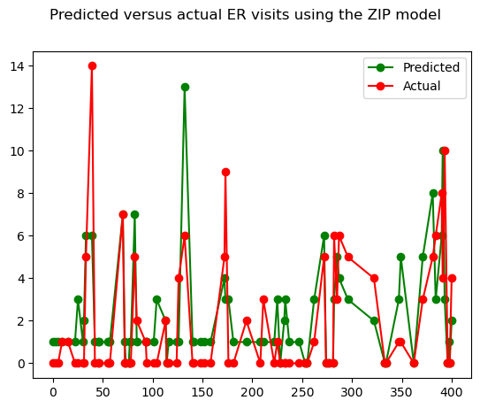

```python
# Sort the test data and predictions by the index
sorted_indices = X_test.index.argsort()
sorted_X_test = X_test.iloc[sorted_indices]
sorted_predicted_counts = predicted_counts.iloc[sorted_indices]
sorted_actual_counts = y_test.iloc[sorted_indices]
fig = plt.figure()
fig.suptitle('Predicted versus actual ER visits using the ZIP model')
predicted = plt.plot(sorted_X_test.index, sorted_predicted_counts, 'go-', label='Predicted')  # 'go-' for green dots connected by lines
actual = plt.plot(sorted_X_test.index, sorted_actual_counts, 'ro-', label='Actual')  # 'ro-' for red dots connected by lines
plt.legend(handles=[predicted[0], actual[0]])
plt.show()
```

```python
X_test.index
```

```
Index([285, 281,  33, 211,  93,  84, 391,  94, 225, 126,   9, 362,  56,  72,
       132,  42, 255, 277, 232, 208,  77,  15, 393, 349,   0, 398, 114, 322,
       381, 104, 397, 194, 262,  57, 333, 116, 113, 400, 158, 141, 334,  55,
        76,  25,  82, 384, 148, 181,  22, 173,  46, 296, 347,  70, 396,  39,
       237, 172,  30, 152, 124, 253, 282,  78, 101,  31, 274, 222, 233,  73,
       287, 140,   5,  45, 390, 247, 228, 371, 176, 272,   3],
      dtype='int64')
```

```python
X_test.index.argsort()
```

```
array([24, 80, 72, 10, 21, 48, 43, 58, 65,  2, 55, 15, 73, 50, 41, 12, 33,
       53, 13, 69, 42, 20, 63, 44,  5,  4,  7, 64, 29, 36, 26, 35, 60,  9,
       14, 71, 39, 46, 59, 38, 57, 49, 78, 47, 31, 19,  3, 67,  8, 76, 18,
       68, 56, 75, 61, 16, 32, 79, 66, 17,  1, 62,  0, 70, 51, 27, 34, 40,
       52, 23, 11, 77, 28, 45, 74,  6, 22, 54, 30, 25, 37], dtype=int64)
```

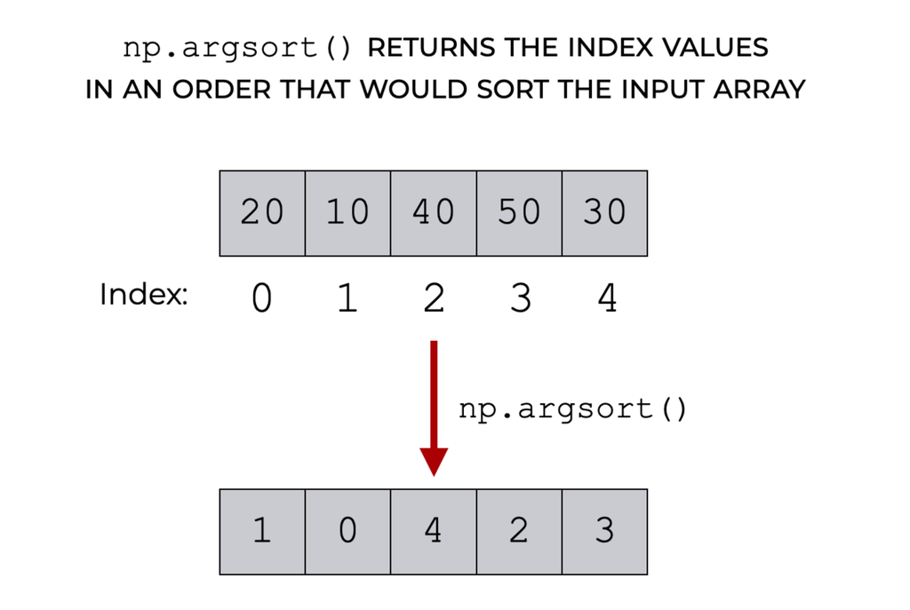

### z-value

#### A high absolute value of the z-score (either positive or negative) indicates that the observed coefficient is far from 0, suggesting a stronger evidence against the null hypothesis (which typically states that the coefficient is equal to zero, implying no effect).

### P>|z| (p-value)

#### The P>|z| value, or p-value, indicates the probability of observing the data (or something more extreme) assuming that the null hypothesis is true. In simpler terms, it helps determine the statistical significance of each coefficient.

#### A small p-value (typically ≤ 0.05) suggests that there is strong evidence against the null hypothesis, allowing us to reject the null hypothesis and conclude that the coefficient is significantly different from 0. This implies that the predictor is likely to have a real effect on the dependent variable.

#### A large p-value suggests that we do not have enough evidence to reject the null hypothesis, and the coefficient may not be significantly different from 0, implying that the predictor may not have a significant effect on the dependent variable.